# Logistic growing model

2020/5/20

## COVID-19预测预报非线性模型及机理简介

在时间序列里，有些变量的增长量最初比较小，随时间的增加逐渐增长而达到一个快速增长时期，而后增长速度趋缓，最终达到稳定的总增长量，这一过程若用曲线来表示，则是一种拉长的S形曲线。这种S形曲线因变量的增长特性的不同而呈现出多样性变化。通常传染病的累计病例遵循S形曲线增长。Logistic函数是一种常见的S形函数，它是皮埃尔·弗朗索瓦·韦吕勒在1844或1845年在研究它与人口增长的关系时命名的。该模型广泛应用于生物繁殖和生长过程、人口增长过程模拟。

Logistic方程,即常微分方程如下：\[\frac {dP} {dt} =rP*(1-\frac {P} {K})\] 将上述方程求解，可以得到logistic函数：\[P(t)=\frac {KP_0 e^rt} {K+P_0(e^rt-1)}\]  
其中\(P_0\)为初始值，\(r\)衡量曲线变化快慢，\(t\)为时间，\(dP/dt\)是种群增长率（单位时间个体数量的改变），\(P\)是种群的大小（个体的数量），\(K\)是可能出现的最大种群数（上渐近线）或承载力。

综上所述，本文将从统计非线性回归的角度来预测和比较各国COVID-19疫情的发展规模，具体聚焦如下问题的研究：（1）用非线性logistic增长曲线模型对各国COVID-19累计确诊病例进行拟合。（2）用非线性logistic增长曲线模型对各国最终流行规模进行预测并进行比较。

## 数据及R程序包说明

-**数据说明**

本文选用2019年GDP前十的国家：美国、中国、日本、德国、印度、法国、英国、巴西、意大利和加拿大。对GDP-TOP10的国家自2019年12月31日至2020年5月8日COVID-19累计确诊病例进行拟合和预测，并对GDP-TOP10的国家最终流行规模的预测值进行比较。

-**R程序包**

本文所采用的R包为**nlrwrb**包中的**nls()**函数，相关使用可参考《Nonlinear Regression with R》。函数**nls()**自带一组自启动函数，即“self-starter functions”，其可以自动设置初始值，Logistic的自启动函数为**SSlogis(x,Asym,xmid,scal)**，其表达式为 \[\frac{Asym}{(1 + exp(\frac{xmid − x}{scal}))}\],与logistic函数表达式略有不同，此处只关注参数**Asym**，其值表示最终流行规模，及logistic函数表达式中的K值。

**注：**此次，我将仅展示利用**nls()**函数对GDP-TOP10国家COVID-19累计确诊病例的拟合和预测，并给出最终流行规模预测值的置信区间。

## 美国COVID-19累计确诊病例的拟合

[output not shown]

```
##
## Formula: US ~ SSlogis(days, Asym1, xmid1, scal1)
##
## Parameters:
##        Estimate Std. Error t value Pr(>|t|)
## Asym1 1.303e+06  1.914e+04   68.07   <2e-16 ***
## xmid1 8.754e+01  3.737e-01  234.26   <2e-16 ***
## scal1 8.904e+00  2.187e-01   40.72   <2e-16 ***
## ---
## Signif. codes:  0 '***' 0.001 '**' 0.01 '*' 0.05 '.' 0.1 ' ' 1
##
## Residual standard error: 23610 on 106 degrees of freedom
##
## Number of iterations to convergence: 0
## Achieved convergence tolerance: 9.176e-07
```

## 美国COVID-19累计确诊病例的预测

```
##        Asym1        xmid1        scal1
## 1.302677e+06 8.753832e+01 8.904278e+00
```

```
##               2.5%        97.5%
## Asym1 1.265432e+06 1.343900e+06
## xmid1 8.679018e+01 8.834887e+01
## scal1 8.494968e+00 9.333665e+00
```

## 美国

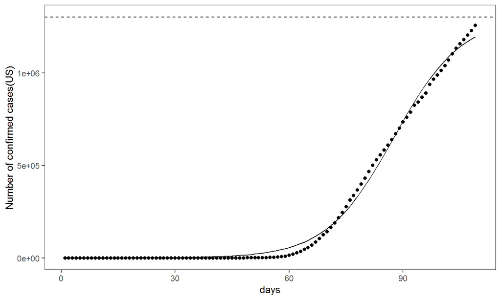

## 中国COVID-19累计确诊病例的拟合

```
##
## Formula: CN ~ SSlogis(days, Asym2, xmid2, scal2)
##
## Parameters:
##        Estimate Std. Error t value Pr(>|t|)
## Asym2 8.238e+04  1.799e+02  458.01   <2e-16 ***
## xmid2 4.152e+01  1.022e-01  406.38   <2e-16 ***
## scal2 4.622e+00  8.908e-02   51.89   <2e-16 ***
## ---
## Signif. codes:  0 '***' 0.001 '**' 0.01 '*' 0.05 '.' 0.1 ' ' 1
##
## Residual standard error: 1527 on 127 degrees of freedom
##
## Number of iterations to convergence: 1
## Achieved convergence tolerance: 3.582e-07
```

## 中国COVID-19累计确诊病例的预测

```
##        Asym2        xmid2        scal2
## 82383.228157    41.523944     4.622036
```

```
##               2.5%        97.5%
## Asym2 82027.279507 82739.805809
## xmid2    41.321858    41.726126
## scal2     4.445662     4.802231
```

## 中国

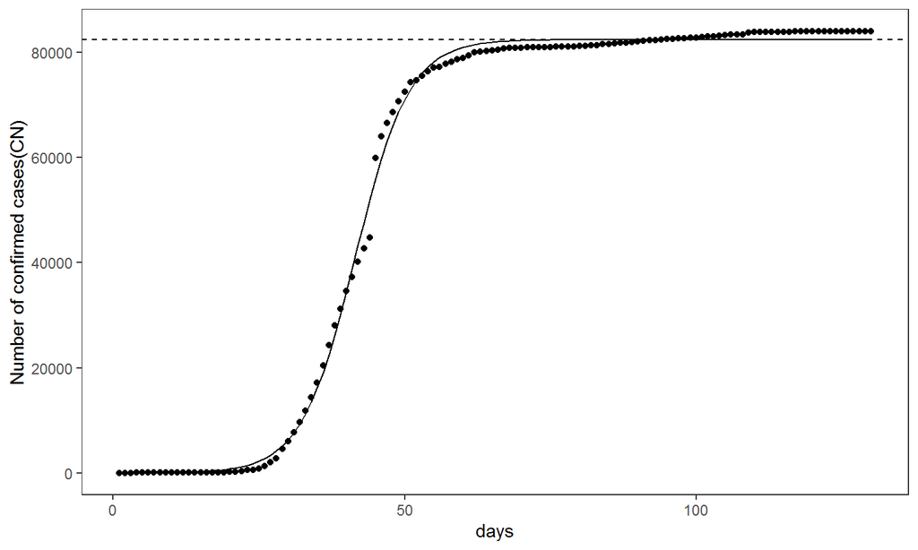

## 日本COVID-19累计确诊病例的拟合

```
##
## Formula: JP ~ SSlogis(days, Asym3, xmid3, scal3)
##
## Parameters:
##        Estimate Std. Error t value Pr(>|t|)
## Asym3 1.652e+04  1.560e+02  105.90   <2e-16 ***
## xmid3 9.263e+01  2.282e-01  405.90   <2e-16 ***
## scal3 7.874e+00  1.479e-01   53.23   <2e-16 ***
## ---
## Signif. codes:  0 '***' 0.001 '**' 0.01 '*' 0.05 '.' 0.1 ' ' 1
##
## Residual standard error: 238.8 on 112 degrees of freedom
##
## Number of iterations to convergence: 0
## Achieved convergence tolerance: 2.702e-06
```

## 日本COVID-19累计确诊病例的预测

```
##        Asym3        xmid3        scal3
## 16516.166160    92.627979     7.873689
```

```
##               2.5%        97.5%
## Asym3 16208.220970 16846.569767
## xmid3    92.182669    93.101041
## scal3     7.562436     8.196972
```

## 日本

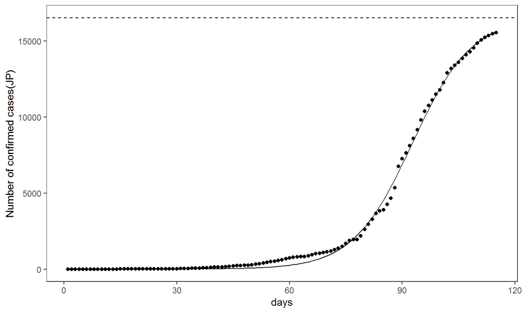

## 德国COVID-19累计确诊病例的拟合

```
##
## Formula: GE ~ SSlogis(days, Asym4, xmid4, scal4)
##
## Parameters:
##        Estimate Std. Error t value Pr(>|t|)
## Asym4 1.620e+05  9.698e+02  167.01   <2e-16 ***
## xmid4 6.800e+01  1.783e-01  381.43   <2e-16 ***
## scal4 7.193e+00  1.430e-01   50.29   <2e-16 ***
## ---
## Signif. codes:  0 '***' 0.001 '**' 0.01 '*' 0.05 '.' 0.1 ' ' 1
##
## Residual standard error: 3079 on 99 degrees of freedom
##
## Number of iterations to convergence: 0
## Achieved convergence tolerance: 3.94e-07
```

## 德国COVID-19累计确诊病例的预测

```
##        Asym4        xmid4        scal4
## 1.619638e+05 6.800128e+01 7.193064e+00
```

```
##               2.5%        97.5%
## Asym4 1.600003e+05 1.639933e+05
## xmid4 6.763189e+01 6.837909e+01
## scal4 6.913947e+00 7.480543e+00
```

## 德国

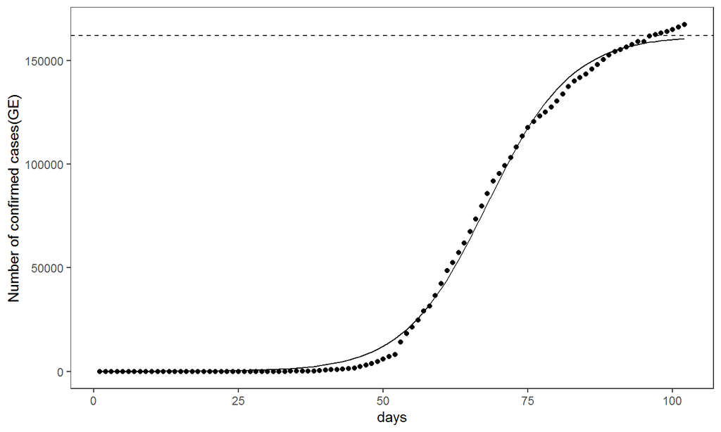

## 印度COVID-19累计确诊病例的拟合

```
##
## Formula: IN ~ SSlogis(days, Asym5, xmid5, scal5)
##
## Parameters:
##        Estimate Std. Error t value Pr(>|t|)
## Asym5 1.037e+05  6.334e+03   16.37   <2e-16 ***
## xmid5 9.905e+01  1.143e+00   86.64   <2e-16 ***
## scal5 1.005e+01  2.516e-01   39.92   <2e-16 ***
## ---
## Signif. codes:  0 '***' 0.001 '**' 0.01 '*' 0.05 '.' 0.1 ' ' 1
##
## Residual standard error: 716.3 on 97 degrees of freedom
##
## Number of iterations to convergence: 0
## Achieved convergence tolerance: 7.289e-07
```

## 印度COVID-19累计确诊病例的预测

```
##        Asym5        xmid5        scal5
## 103676.77510     99.05399     10.04561
```

```
##               2.5%        97.5%
## Asym5 92821.947669 118492.36839
## xmid5    96.994901    101.53101
## scal5     9.582624     10.53659
```

## 印度

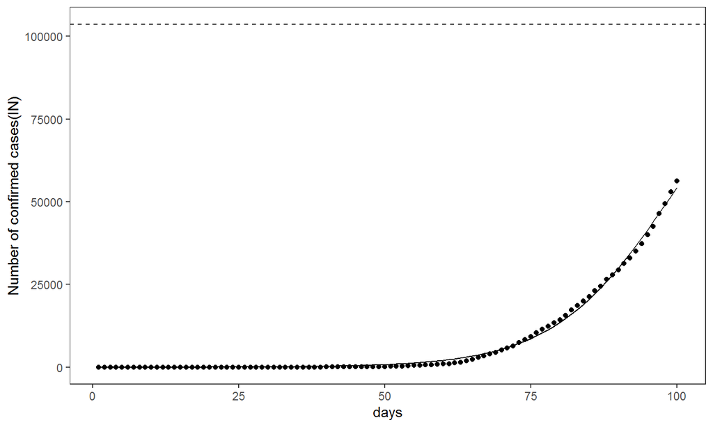

## 法国COVID-19累计确诊病例的拟合

```
##
## Formula: FR ~ SSlogis(days, Asym6, xmid6, scal6)
##
## Parameters:
##        Estimate Std. Error t value Pr(>|t|)
## Asym6 1.328e+05  6.794e+02  195.42   <2e-16 ***
## xmid6 7.237e+01  1.497e-01  483.48   <2e-16 ***
## scal6 7.429e+00  1.178e-01   63.07   <2e-16 ***
## ---
## Signif. codes:  0 '***' 0.001 '**' 0.01 '*' 0.05 '.' 0.1 ' ' 1
##
## Residual standard error: 1983 on 102 degrees of freedom
##
## Number of iterations to convergence: 0
## Achieved convergence tolerance: 1.105e-06
```

## 法国COVID-19累计确诊病例的预测

```
##        Asym6        xmid6        scal6
## 1.327671e+05 7.237489e+01 7.428983e+00
```

```
##               2.5%        97.5%
## Asym6 1.314002e+05 1.341754e+05
## xmid6 7.206809e+01 7.268807e+01
## scal6 7.198583e+00 7.665139e+00
```

## 法国

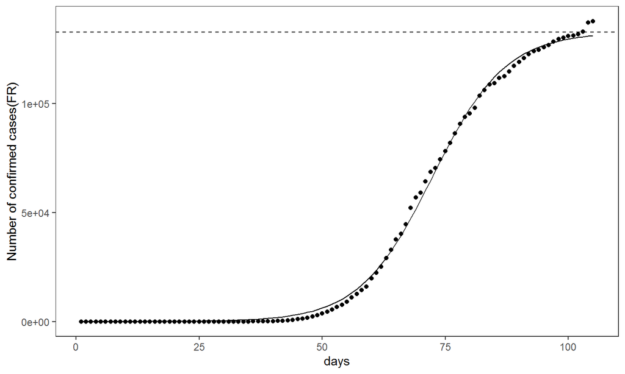

## 英国COVID-19累计确诊病例的拟合

```
##
## Formula: UK ~ SSlogis(days, Asym7, xmid7, scal7)
##
## Parameters:
##        Estimate Std. Error t value Pr(>|t|)
## Asym7 2.165e+05  3.064e+03   70.67   <2e-16 ***
## xmid7 7.914e+01  3.487e-01  226.95   <2e-16 ***
## scal7 8.874e+00  1.946e-01   45.60   <2e-16 ***
## ---
## Signif. codes:  0 '***' 0.001 '**' 0.01 '*' 0.05 '.' 0.1 ' ' 1
##
## Residual standard error: 3339 on 96 degrees of freedom
##
## Number of iterations to convergence: 0
## Achieved convergence tolerance: 3.594e-07
```

## 英国COVID-19累计确诊病例的预测

```
##        Asym7        xmid7        scal7
## 2.165179e+05 7.914024e+01 8.873577e+00
```

```
##               2.5%        97.5%
## Asym7 2.105393e+05 2.231136e+05
## xmid7 7.844422e+01 7.989313e+01
## scal7 8.503674e+00 9.260053e+00
```

## 英国

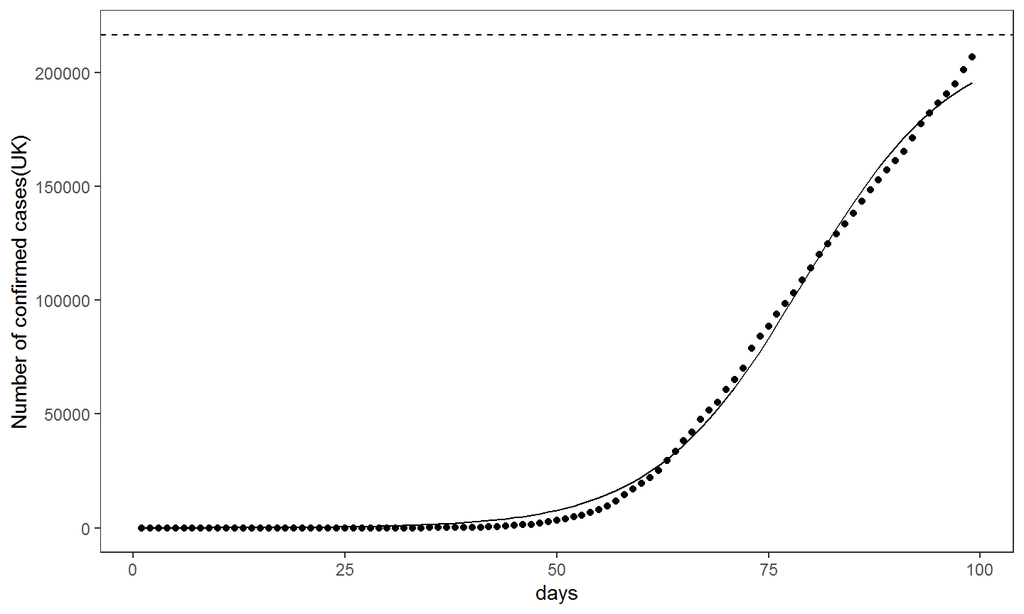

## 巴西COVID-19累计确诊病例的拟合

```
##
## Formula: BR ~ SSlogis(days, Asym8, xmid8, scal8)
##
## Parameters:
##        Estimate Std. Error t value Pr(>|t|)
## Asym8 3.651e+05  3.510e+04   10.40 7.59e-16 ***
## xmid8 7.938e+01  1.724e+00   46.03  < 2e-16 ***
## scal8 1.113e+01  2.524e-01   44.08  < 2e-16 ***
## ---
## Signif. codes:  0 '***' 0.001 '**' 0.01 '*' 0.05 '.' 0.1 ' ' 1
##
## Residual standard error: 1474 on 70 degrees of freedom
##
## Number of iterations to convergence: 0
## Achieved convergence tolerance: 2.166e-06
```

## 巴西COVID-19累计确诊病例的预测

```
##        Asym8        xmid8        scal8
## 365061.82176     79.37702     11.12816
```

```
##               2.5%        97.5%
## Asym8 309141.77047 452198.55398
## xmid8     76.38755     83.15796
## scal8     10.66211     11.62042
```

## 巴西

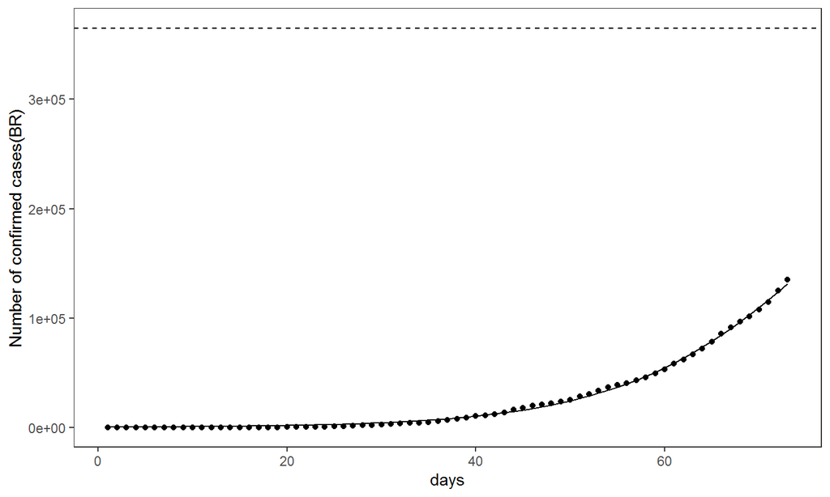

## 意大利COVID-19累计确诊病例的拟合

```
##
## Formula: IT ~ SSlogis(days, Asym9, xmid9, scal9)
##
## Parameters:
##        Estimate Std. Error t value Pr(>|t|)
## Asym9 2.117e+05  1.868e+03  113.34   <2e-16 ***
## xmid9 6.310e+01  2.975e-01  212.08   <2e-16 ***
## scal9 9.356e+00  2.234e-01   41.88   <2e-16 ***
## ---
## Signif. codes:  0 '***' 0.001 '**' 0.01 '*' 0.05 '.' 0.1 ' ' 1
##
## Residual standard error: 5007 on 96 degrees of freedom
##
## Number of iterations to convergence: 0
## Achieved convergence tolerance: 9.198e-07
```

## 意大利COVID-19累计确诊病例的预测

```
##        Asym9        xmid9        scal9
## 211728.01771     63.09782      9.35586
```

```
##               2.5%        97.5%
## Asym9 2.079657e+05 215708.65607
## xmid9 6.247884e+01     63.74275
## scal9 8.927128e+00      9.80178
```

## 意大利

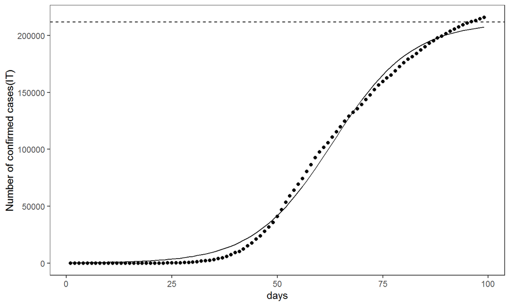

## 加拿大COVID-19累计确诊病例的拟合

```
##
## Formula: CA ~ SSlogis(days, Asym10, xmid10, scal10)
##
## Parameters:
##         Estimate Std. Error t value Pr(>|t|)
## Asym10 7.326e+04  1.433e+03   51.13   <2e-16 ***
## xmid10 8.659e+01  4.912e-01  176.26   <2e-16 ***
## scal10 9.760e+00  2.367e-01   41.24   <2e-16 ***
## ---
## Signif. codes:  0 '***' 0.001 '**' 0.01 '*' 0.05 '.' 0.1 ' ' 1
##
## Residual standard error: 1133 on 101 degrees of freedom
##
## Number of iterations to convergence: 0
## Achieved convergence tolerance: 2.21e-06
```

## 加拿大COVID-19累计确诊病例的预测

```
##      Asym10      xmid10      scal10
## 73260.84563    86.58605     9.76043
```

```
##                2.5%       97.5%
## Asym10 70570.349248 76317.28871
## xmid10    85.643264    87.62688
## scal10     9.324996    10.21844
```

## 加拿大

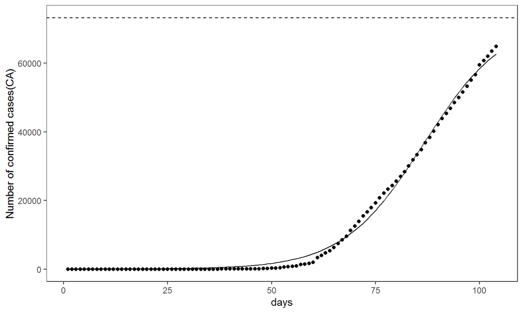